# Biostat 203B Homework 4 (Draft)

Due Mar 12 @ 11:59PM

Load database libraries and the tidyverse frontend:

```r
setwd("/home/mia.chen1998/biostat-203b-2021-winter/hw4")
library(tidyverse)
library(lubridate)
library(miceRanger)
library(dplyr)
library(data.table)
```

## Q1. Missing data

Through the Shiny app developed in HW3, we observe abundant missing values in the MIMIC-IV ICU cohort we created. In this question, we use multiple imputation to obtain a data set without missing values.

0. Read following tutorials on the R package miceRanger for imputation: https://github.com/farrellday/miceRanger, https://cran.r-project.org/web/packages/miceRanger/vignettes/miceAlgorithm.html.

   A more thorough book treatment of the practical imputation strategies is the book [*Flexible Imputation of Missing Data*](https://stefvanbuuren.name/fimd/) by Stef van Buuren.

**Solution:** Done

1. Explain the jargon MCAR, MAR, and MNAR.

**Solution:**

MCAR: data are missing completely at random. i.e. the probability of being missing is the same for all case.

MAR: data are missing at random. i.e. the probability of being missing is the same only within groups defined by the observed data.

MNAR: data are not missing at random. i.e. the probability of being missing varies for reasons that are unknown to us.

2. Explain in a couple of sentences how the Multiple Imputation by Chained Equations (MICE) work.

**Solution:**

Multiple Imputation by Chained Equations (MICE): it is an effective way to deal with missing data in the dataset. The term ‘imputation’ means filling the missing data in a dataset through an iterative series of predictive models. At each iteration, the missing values are predicted by the other non-missing data in the dataset. The iteration will stop when convergence has met.

3. Perform a data quality check of the ICU stays data. Discard variables with substantial missingness, say >5000 `NA`s. Replace apparent data entry errors by `NA`s.

```r
# Read data
df <- readRDS("icu_cohort.rds")

# Delete Columns with more than 5000 missing values
sapply(df, function(x) sum(is.na(x)))
```

```
##                           subject_id                              hadm_id
##                                    0                                    0
##                              stay_id                       first_careunit
##                                    0                                    0
##                        last_careunit                               intime
##                                    0                                    0
##                              outtime                                  los
##                                    0                                    0
##                               gender                           anchor_age
##                                    0                                    0
##                          anchor_year                    anchor_year_group
##                                    0                                    0
##                                  dod                            admittime
##                                50048                                    0
##                            dischtime                            deathtime
##                                    0                                44872
##                       admission_type                   admission_location
##                                    0                                    0
##                   discharge_location                            insurance
##                                  452                                    0
##                             language                       marital_status
##                                    0                                 4176
##                            ethnicity                            edregtime
##                                    0                                18462
##                            edouttime                 hospital_expire_flag
##                                18462                                    0
##                           age_at_adm                          bicarbonate
##                                    0                                  861
##                              calcium                             chloride
##                                 2374                                  835
##                           creatinine                              glucose
##                                  839                                  850
##                            magnesium                            potassium
##                                 1017                                  852
##                               sodium                           hematocrit
##                                  826                                 1016
##                                  wbc                              lactate
##                                 1032                                19843
##                           heart_rate non_invasive_blood_pressure_systolic
##                                    8                                  572
##     non_invasive_blood_pressure_mean                     respiratory_rate
##                                  593                                   34
##               temperature_fahrenheit     arterial_blood_pressure_systolic
##                                  827                                29019
##         arterial_blood_pressure_mean                            deathin30
##                                28897                                44872
```

```r
# Choose all the numeric variables with <5000 missing values
selected_cols = c('bicarbonate', 'calcium', 'chloride',
                  'creatinine','glucose','magnesium',
                  'potassium,sodium', 'hematocrit', 'wbc',
                  'heart_rate', 'respiratory_rate',
                  'non_invasive_blood_pressure_systolic',
                  'non_invasive_blood_pressure_mean',
                  'temperature_fahrenheit')

icu_tble <- setDT(df[ , names(df) %in% selected_cols])
head(icu_tble, 10)
```

[output not shown]

4. Impute missing values by `miceRanger` (request $m=3$ datasets). This step is very computational intensive. Make sure to save the imputation results as a file.

```r
require(miceRanger)
seqTime <- system.time(
  miceObj <- miceRanger(
    icu_tble
    , m = 3
    , max.depth = 5
    , returnModels = TRUE
    , verbose = TRUE
  )
)
miceObj %>%
  saveRDS(str_c("/home/mia.chen1998/biostat-203b-2021-winter/hw4/Obj.rds"))
```

5. Make imputation diagnostic plots and explain what they mean.

```r
Obj = readRDS("Obj.rds")
```

First we can check the plot of distribution for the original dataset (in red) with the imputed dataset (in black). As we can see most of them matched well. Unmatchness might arise for heart rate and respiratory rate with the lines slightly unmatched. It would not cause a big problem but just telling us these two variables were not missing completely at random.

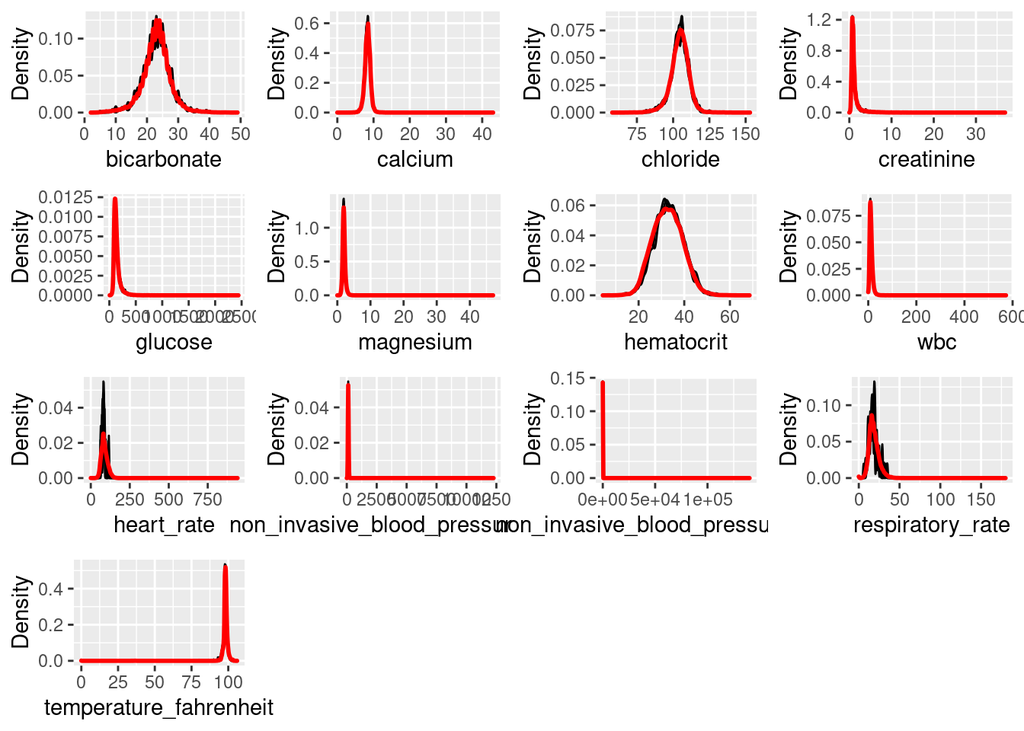

```r
# Distribution of Imputed Values
plotDistributions(Obj, vars = 'allNumeric')
```

These plots will show us how values between datasets converged over the iterations.

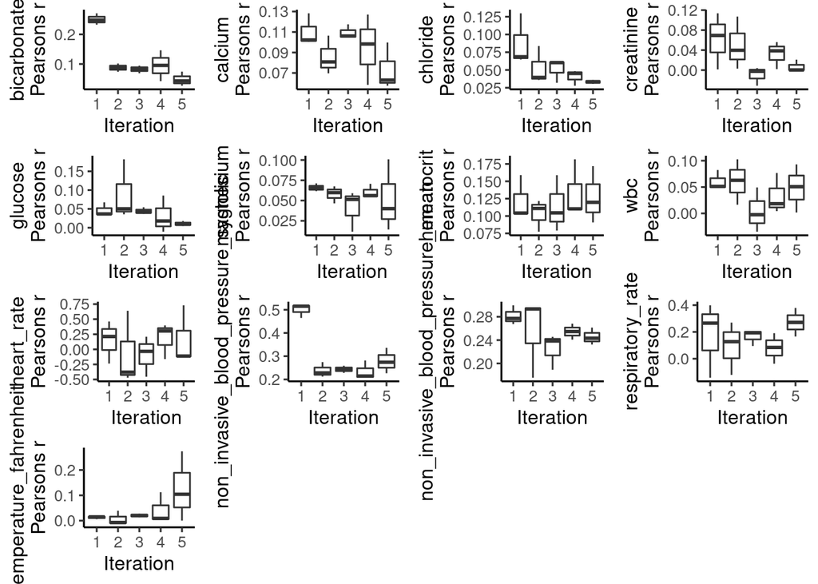

```r
# Convergence of Correlation
plotCorrelations(Obj,vars='allNumeric')
```

These plots are helping us check if there is any convergence issue. The convergence issue arise when the missing data locations are correlated with higher or lower values.

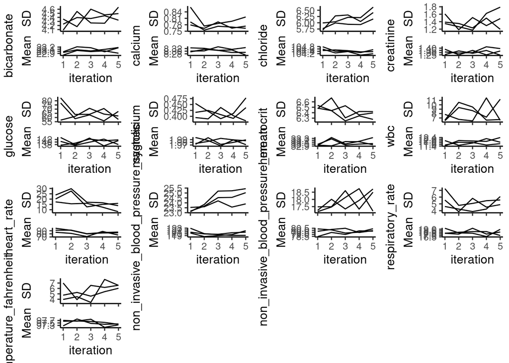

```r
# Center and Dispersion Convergence
plotVarConvergence(Obj,vars='allNumeric')
```

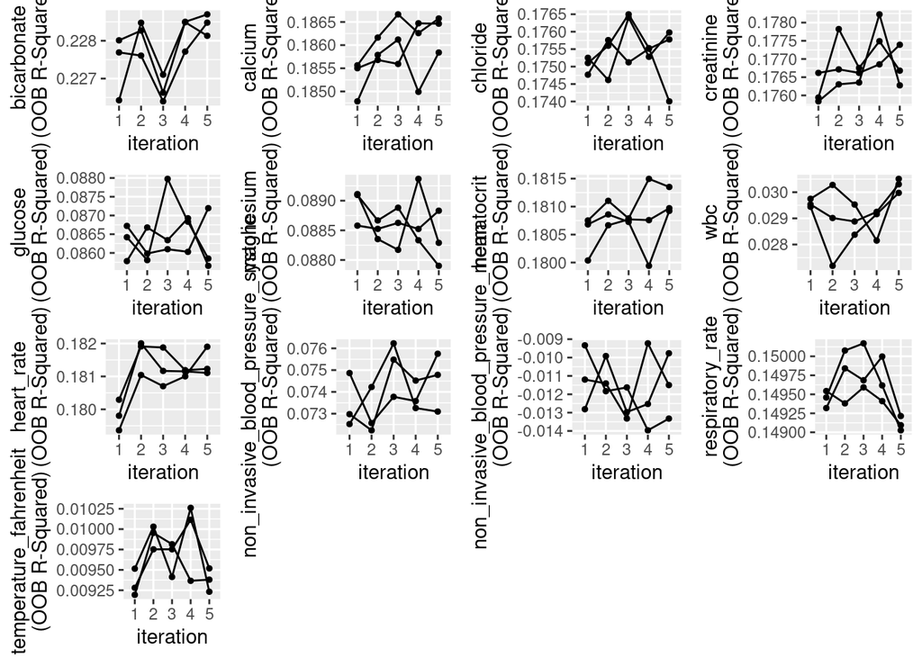

```r
# Model OOB Error
plotModelError(Obj,vars='allNumeric')
```

In this plot, the top axis contains the variable that was used to impute the variable on the left axis.

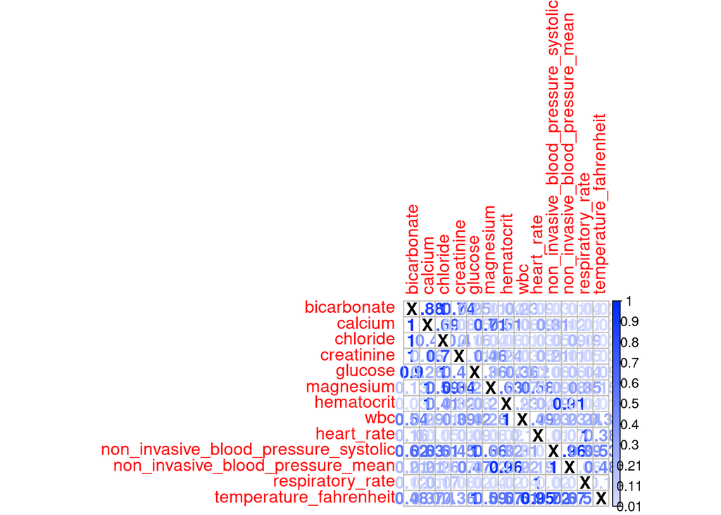

```r
# Variable Importance
plotVarImportance(Obj)
```

Finally we can check the the variance experienced for each imputed value between the datasets by the following commands.

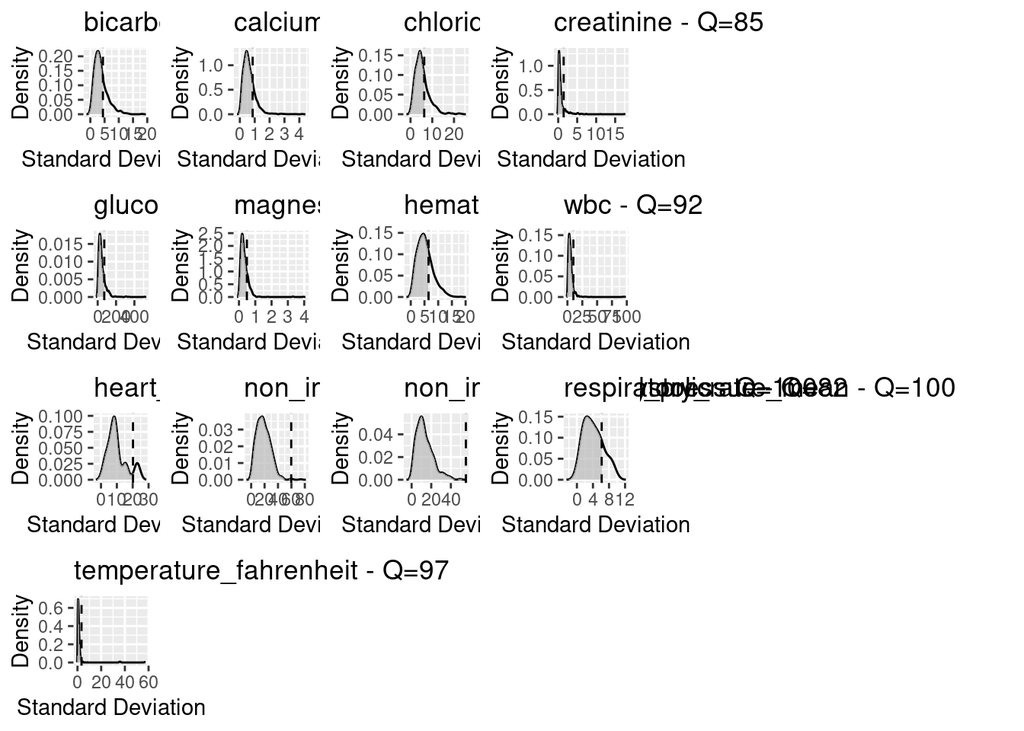

```r
# Imputed Variance Between Datasets
plotImputationVariance(Obj,ncol=2,widths=c(5,3))
```

6. Obtain a complete data set by averaging the 3 imputed data sets.

```r
dataList <- completeData(Obj)
head(dataList[[1]],10)
```

```
##     bicarbonate calcium chloride creatinine glucose magnesium hematocrit  wbc
##  1:          23     9.2      103        2.2     144       2.0       30.8  5.4
##  2:          24     9.5      109        3.4      86       2.2       30.9  7.4
##  3:          19     8.0      107        0.8      89       1.7       26.4 20.7
##  4:          23     7.5      109        0.7     124       1.9       21.2  9.2
##  5:          26     9.7      103        1.0     204       2.3       36.6  6.7
##  6:          23     8.4      113        1.0     115       2.2       25.9  5.3
##  7:          26     7.7      107        0.6     102       1.8       31.6  4.4
##  8:          19     8.2      108        1.2     115       2.1       32.1 14.1
##  9:          33    10.0      103        0.3     116       2.0       35.5 13.2
## 10:          21     9.0      106        0.5     159       2.1       34.6  4.9
##     heart_rate non_invasive_blood_pressure_systolic
##  1:         77                                  150
##  2:         87                                  167
##  3:        114                                  109
```

[output cut: 18 more lines]

## Q2. Predicting 30-day mortality

Develop at least two analytic approaches for predicting the 30-day mortality of patients admitted to ICU using demographic information (gender, age, marital status, ethnicity), first lab measurements during ICU stay, and first vital measurements during ICU stay. For example, you can use (1) logistic regression (`glm()` function), (2) logistic regression with lasso penalty (glmnet package), (3) random forest (randomForest package), or (4) neural network.

```r
icu_cohort <- readRDS("icu_cohort.rds") %>%
  print(width = Inf)  %>%
  mutate_at(vars(deathin30),
            function(x){
              ifelse(is.na(x) == TRUE, "No", x)
              })
```

```
## # A tibble: 50,048 x 46
##    subject_id  hadm_id  stay_id first_careunit
##         <int>    <int>    <int> <chr>
##  1   10000980 26913865 36742749 Medical Intensive Care Unit (MICU)
##  2   10004733 27411876 37003946 Medical/Surgical Intensive Care Unit (MICU/SICU)
##  3   10006821 23295760 30272829 Medical/Surgical Intensive Care Unit (MICU/SICU)
##  4   10009628 25926192 31786068 Cardiac Vascular Intensive Care Unit (CVICU)
##  5   10012261 27493974 30741264 Trauma SICU (TSICU)
##  6   10012552 27089790 36574633 Cardiac Vascular Intensive Care Unit (CVICU)
##  7   10013419 29669860 31631748 Surgical Intensive Care Unit (SICU)
##  8   10014610 23258342 30950011 Cardiac Vascular Intensive Care Unit (CVICU)
##  9   10016742 29281842 39410091 Surgical Intensive Care Unit (SICU)
## 10   10017308 29888008 36392624 Neuro Surgical Intensive Care Unit (Neuro SICU)
##    last_careunit                                    intime
##    <chr>                                            <dttm>
```

[output cut: 119 more lines]

```r
deathin30 <- icu_cohort$deathin30
  # %>%
  # mutate_at(vars(deathin30),
  #           function(x){
  #             ifelse(x == "Yes", 1, 0)
  #           }) %>%
  # mutate_at(vars(deathin30),
  #           function(x){
  #             ifelse(is.na(x) == TRUE, 0, x)
  #             })
```

Choose the columns with the categorical vars as required + the numerical vars with no more than 5000 missing values + subject_id + 30-day mortality indicator.

```r
selected_cols_2 = c('gender','anchor_age','marital_status','ethnicity',
                  'bicarbonate', 'calcium', 'chloride',
                  'creatinine','glucose','magnesium',
                  'potassium','sodium', 'hematocrit', 'wbc',
                  'heart_rate', 'respiratory_rate',
                  'non_invasive_blood_pressure_systolic',
                  'non_invasive_blood_pressure_mean',
                  'temperature_fahrenheit', 'deathin30')

icu <- setDT(icu_cohort[ , names(df) %in% selected_cols_2])
head(icu, 10)
summary(icu)
```

[output not shown]

Identify and remove the outliers

```r
library(tidyverse)
columns_to_do <- names(select_if(icu, is.numeric))

do_col <- function(c){
b <- boxplot(c, plot = FALSE)
s1 <- c
s1[which(c %in% b$out)] = NA
return(s1)
}

icu1 <- mutate_if(icu, is.numeric, do_col)
```

Impute the dataset with miceRanger:

```r
require(miceRanger)
seqTime <- system.time(
  miceObj <- miceRanger(
    icu1
    , m = 3
    , max.depth = 10
    , returnModels = TRUE
    , verbose = TRUE
  )
)

saveRDS(miceObj, file="icu_MICE.rds")
```

Read in the imputed datasets and take the average:

```r
Obj1 <- readRDS("icu_MICE.rds")
ICU <- completeData(Obj1)
dummy <- c('gender', 'marital_status')
d <- as.data.frame(ICU$Dataset_1)
d1 <- data.matrix(ICU$Dataset_1)
d2 <- data.matrix(ICU$Dataset_2)
d3 <- data.matrix(ICU$Dataset_3)
d4 <- as.data.frame((d1 + d2 + d3)/3)
d4$gender <- as.numeric(as.factor(d$gender))
d4$marital_status <- as.numeric(as.factor(d$marital_status))
d4$ethnicity <- as.numeric(as.factor(d$ethnicity))
d4$deathin30 <- icu_cohort$deathin30
# d4 is the dataframe we going to use eventually
is.data.frame(d4)
```

```
## [1] TRUE
```

```r
summary(d4)
```

```
##    subject_id           gender     marital_status    ethnicity
##  Min.   :10000032   Min.   :1.00   Min.   :1.000   Min.   :1.000
##  1st Qu.:12485686   1st Qu.:1.00   1st Qu.:2.000   1st Qu.:7.000
##  Median :14997274   Median :2.00   Median :2.000   Median :8.000
##  Mean   :14993100   Mean   :1.56   Mean   :2.487   Mean   :6.939
##  3rd Qu.:17501993   3rd Qu.:2.00   3rd Qu.:3.000   3rd Qu.:8.000
##  Max.   :19999987   Max.   :2.00   Max.   :4.000   Max.   :8.000
##   bicarbonate       calcium          chloride       creatinine
##  Min.   :13.50   Min.   : 6.600   Min.   : 91.0   Min.   :0.0000
##  1st Qu.:21.00   1st Qu.: 7.900   1st Qu.:101.0   1st Qu.:0.7000
##  Median :23.00   Median : 8.400   Median :105.0   Median :0.9000
##  Mean   :23.17   Mean   : 8.345   Mean   :104.8   Mean   :0.9837
##  3rd Qu.:25.00   3rd Qu.: 8.800   3rd Qu.:108.0   3rd Qu.:1.2000
##  Max.   :33.00   Max.   :10.100   Max.   :118.0   Max.   :2.2000
##     glucose      magnesium       potassium         sodium        hematocrit
##  Min.   : 24   Min.   :1.000   Min.   :2.600   Min.   :129.0   Min.   :14.50
##  1st Qu.:103   1st Qu.:1.700   1st Qu.:3.700   1st Qu.:136.0   1st Qu.:28.20
##  Median :122   Median :1.933   Median :4.100   Median :139.0   Median :32.60
##  Mean   :128   Mean   :1.962   Mean   :4.107   Mean   :138.7   Mean   :32.71
##  3rd Qu.:148   3rd Qu.:2.200   3rd Qu.:4.500   3rd Qu.:141.0   3rd Qu.:37.20
##  Max.   :235   Max.   :2.900   Max.   :5.600   Max.   :148.0   Max.   :50.80
##       wbc          heart_rate     non_invasive_blood_pressure_systolic
##  Min.   : 0.00   Min.   : 37.00   Min.   : 57
##  1st Qu.: 7.60   1st Qu.: 74.00   1st Qu.:106
##  Median :10.40   Median : 85.00   Median :122
##  Mean   :10.96   Mean   : 86.73   Mean   :123
##  3rd Qu.:13.80   3rd Qu.: 98.00   3rd Qu.:139
##  Max.   :24.60   Max.   :136.00   Max.   :188
##  non_invasive_blood_pressure_mean respiratory_rate temperature_fahrenheit
##  Min.   : 33.00                   Min.   : 5.00    Min.   : 96.00
##  1st Qu.: 69.00                   1st Qu.:15.00    1st Qu.: 97.70
##  Median : 80.00                   Median :18.00    Median : 98.10
##  Mean   : 81.41                   Mean   :18.27    Mean   : 98.15
##  3rd Qu.: 92.00                   3rd Qu.:22.00    3rd Qu.: 98.60
##  Max.   :129.00                   Max.   :32.00    Max.   :100.30
##   deathin30
##  Length:50048
##  Class :character
##  Mode  :character
##
##
##
```

Now we can use the imputed dataset to predict the 30-day mortality status.

**Solution:** Method 1: Random Forest

Load the required packages.

```r
library(randomForest)
library(caret)
library(caTools)
library(e1071)
```

Partition data into 80% training set and 20% test set. Stratify partitioning according the 30-day mortality status.

```r
sample = sample.split(d4$deathin30, SplitRatio = .8)
train = subset(d4, sample == TRUE)
test = subset(d4, sample == FALSE)
trainControl(method = "cv", number = 5, search ="grid")
```

[output not shown]

[output cut: 60 more lines]

[output not shown]

```r
trControl <- trainControl(method = "cv",
    number = 5,
    search = "grid")
summary(train)
```

```
##    subject_id           gender      marital_status    ethnicity
##  Min.   :10000032   Min.   :1.000   Min.   :1.000   Min.   :1.000
##  1st Qu.:12462842   1st Qu.:1.000   1st Qu.:2.000   1st Qu.:7.000
##  Median :14978282   Median :2.000   Median :2.000   Median :8.000
##  Mean   :14977123   Mean   :1.561   Mean   :2.481   Mean   :6.945
##  3rd Qu.:17475757   3rd Qu.:2.000   3rd Qu.:3.000   3rd Qu.:8.000
##  Max.   :19999840   Max.   :2.000   Max.   :4.000   Max.   :8.000
##   bicarbonate       calcium          chloride       creatinine
##  Min.   :13.50   Min.   : 6.600   Min.   : 91.0   Min.   :0.0000
##  1st Qu.:21.00   1st Qu.: 7.900   1st Qu.:101.0   1st Qu.:0.7000
##  Median :23.00   Median : 8.400   Median :105.0   Median :0.9000
##  Mean   :23.17   Mean   : 8.346   Mean   :104.8   Mean   :0.9828
##  3rd Qu.:25.00   3rd Qu.: 8.800   3rd Qu.:108.0   3rd Qu.:1.2000
##  Max.   :33.00   Max.   :10.100   Max.   :118.0   Max.   :2.2000
##     glucose      magnesium       potassium         sodium        hematocrit
##  Min.   : 24   Min.   :1.000   Min.   :2.600   Min.   :129.0   Min.   :14.5
##  1st Qu.:103   1st Qu.:1.700   1st Qu.:3.700   1st Qu.:136.0   1st Qu.:28.2
##  Median :122   Median :1.933   Median :4.100   Median :139.0   Median :32.7
##  Mean   :128   Mean   :1.963   Mean   :4.109   Mean   :138.7   Mean   :32.7
##  3rd Qu.:148   3rd Qu.:2.200   3rd Qu.:4.500   3rd Qu.:141.0   3rd Qu.:37.1
##  Max.   :235   Max.   :2.900   Max.   :5.600   Max.   :148.0   Max.   :50.8
##       wbc          heart_rate     non_invasive_blood_pressure_systolic
##  Min.   : 0.00   Min.   : 37.00   Min.   : 57.0
##  1st Qu.: 7.60   1st Qu.: 74.00   1st Qu.:106.0
##  Median :10.40   Median : 85.00   Median :122.0
##  Mean   :10.96   Mean   : 86.67   Mean   :123.1
##  3rd Qu.:13.80   3rd Qu.: 98.00   3rd Qu.:139.0
##  Max.   :24.60   Max.   :136.00   Max.   :188.0
##  non_invasive_blood_pressure_mean respiratory_rate temperature_fahrenheit
##  Min.   : 33.00                   Min.   : 5.00    Min.   : 96.00
##  1st Qu.: 70.00                   1st Qu.:15.00    1st Qu.: 97.70
##  Median : 80.00                   Median :18.00    Median : 98.10
##  Mean   : 81.41                   Mean   :18.25    Mean   : 98.15
##  3rd Qu.: 92.00                   3rd Qu.:22.00    3rd Qu.: 98.60
##  Max.   :129.00                   Max.   :32.00    Max.   :100.30
##   deathin30
##  Length:40038
##  Class :character
##  Mode  :character
##
##
##
```

Train the models using the training set.

```r
rf <- train(deathin30 ~.,
    data = train,
    method = "rf",
    metric = "Accuracy",
    trControl = trControl,
    nodesize = 19,
    ntree = 10)
print(rf)
```

```
## Random Forest
##
## 40038 samples
##    19 predictor
##     2 classes: 'No', 'Yes'
##
## No pre-processing
## Resampling: Cross-Validated (5 fold)
## Summary of sample sizes: 32031, 32030, 32031, 32029, 32031
## Resampling results across tuning parameters:
##
##   mtry  Accuracy   Kappa
##    2    0.9011939  0.04037541
##   10    0.8982217  0.08250453
##   19    0.8969229  0.09582951
##
## Accuracy was used to select the optimal model using the largest value.
## The final value used for the model was mtry = 2.
```

```r
rf$bestTune$mtry
```

```
## [1] 2
```

```r
max(rf$results$Accuracy)
```

```
## [1] 0.9011939
```

Required packages.

```r
library(caret)
library(broom)
library(glmnet)
```

Prepare the training and testing dataset.

```r
d5 <- d4 %>%
  mutate_at(vars(deathin30),
            function(x){
              ifelse(x == "Yes", 1, 0)
              })
sample1 = sample.split(d5$deathin30, SplitRatio = .8)
train1 = subset(d5, sample == TRUE)
test1 = subset(d5, sample == FALSE)

x_train = subset(train1[1:19]) %>% data.matrix()
y_train = train1$deathin30 %>% data.matrix()
x_test = subset(test1[1:19]) %>% data.matrix()
y_test = subset(test1[20]) %>% data.matrix()
```

Train the model and predict the values.

```r
lambdas <- 10^seq(3, -2, by = -.1)
fit <- glmnet(x_train, y_train, alpha = 0, lambda = lambdas)
summary(fit)
```

```
##           Length Class     Mode
## a0         51    -none-    numeric
## beta      969    dgCMatrix S4
## df         51    -none-    numeric
## dim         2    -none-    numeric
## lambda     51    -none-    numeric
## dev.ratio  51    -none-    numeric
## nulldev     1    -none-    numeric
## npasses     1    -none-    numeric
## jerr        1    -none-    numeric
## offset      1    -none-    logical
## call        5    -none-    call
## nobs        1    -none-    numeric
```

```r
cv_fit <- cv.glmnet(x_train, y_train, alpha = 0, lambda = lambdas)

# Get the opt_lamda
opt_lambda <- cv_fit$lambda.min
opt_lambda
```

```
## [1] 0.01
```

```r
fit <- cv_fit$glmnet.fit
y_predicted <- predict(fit, s = opt_lambda, newx = x_test)

# R-Squared
R2 <- sum((y_predicted - y_test)^2) / sum((y_test - mean(y_test))^2)
R2
```

```
## [1] 0.9351585
```

Thank you for your time.